# Peer Assessment 1

James Bullis

Saturday, October 18, 2014

### Loading and Preprocessing Data

The packages plyr and ggplot2 will be used for preoprocessing and data analysis. Once the data has been imported, dates were converted into Date format. An additional factor was created that specifies whether a day is a weekend or weekday.

```r
library(ggplot2)
library(plyr)

WD <-getwd()
setwd(paste(WD, "/activity", sep=""))
activity <- read.csv("activity.csv", header=TRUE)
activity$date <-as.Date(activity$date)
day <-weekdays(activity$date)
activity$daytype <-"weekend"
activity$daytype[!weekdays(activity$date) %in% c('Saturday', 'Sunday')]<-"weekday"
```

### What is the mean total number of steps taken per day?

For this section, NA values are removed for analysis. The mean number of steps is specfied in the summary below. Following is a histogram for the sum of the number of steps taken for each day.

```r
activity.clean <-subset(activity, activity$steps >=0)
activity.clean <-droplevels(activity.clean)
activity.sums <-tapply(activity.clean$steps, list(activity.clean$date), sum)
summary(activity.sums)
```

```
##    Min. 1st Qu.  Median    Mean 3rd Qu.    Max.
##      41    8841   10760   10770   13290   21190
```

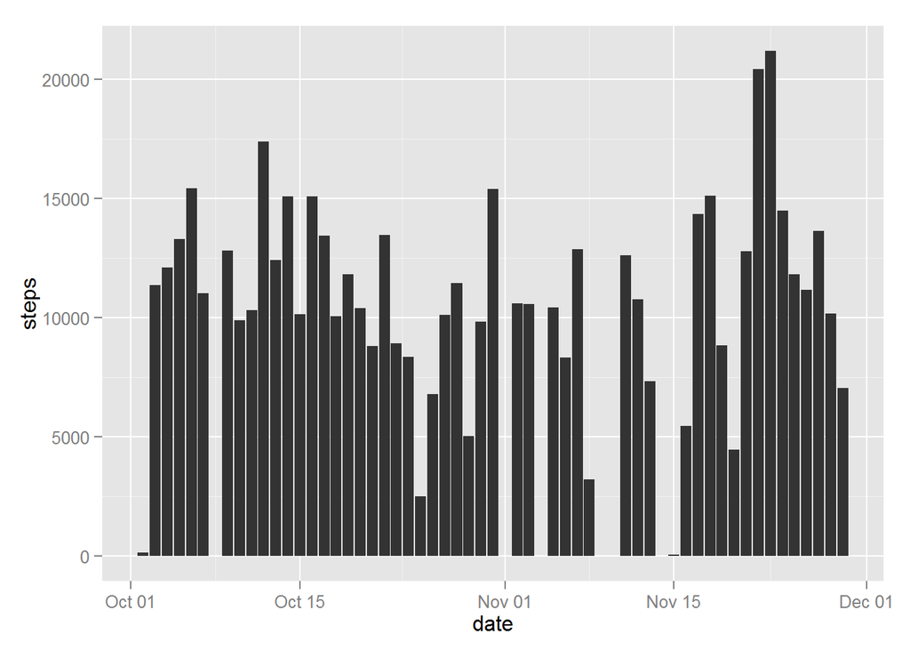

```r
sums.df <-ldply(activity.sums)
names(sums.df) <-c("date", "steps")
sums.df$date <- as.Date(sums.df$date)
sums.plot <-ggplot(sums.df, aes(x=date, y=steps)) + geom_bar(stat="identity")
sums.plot
```

### What is the average daily pattern?

To measure daily pattern, a new dataframe was created that calculated the mean value for each interval across the days and plotted below. Following the graph, the interval containing the maximum number of steps is printed.

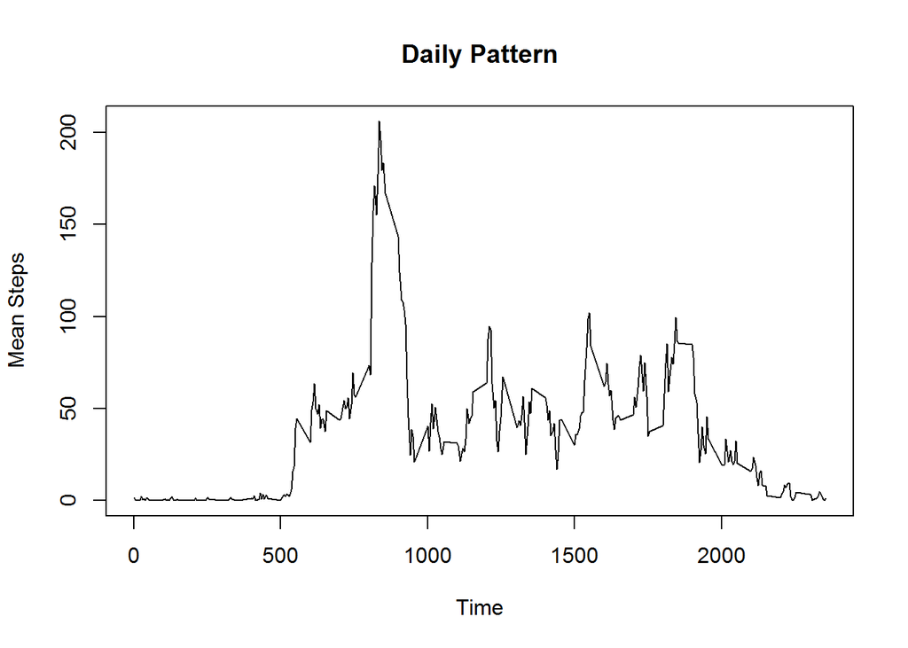

```r
daily.pattern <-tapply(activity.clean$steps, list(activity.clean$interval), mean)
plot(x=names(daily.pattern), y=daily.pattern, main="Daily Pattern", xlab="Time", ylab="Mean Steps", type="l")
```

```r
names(which(daily.pattern ==(max(daily.pattern))))
```

```
## [1] "835"
```

### Imputing Missing Values

Missing values may introduce bias into the data. To test this, a new dataset was created. NA’s from the original data were replaced with the average value of that interval. The specific value was dependent upon whether the day was a weekend or weekday, as the patterns of activity were different between the two (see “Are there differences in activty patterns between weekdays and weekends?”).

In the code below, the first section separates the data into weekday and weekend days and computes the means for each interval, which is used as a lookup table for imputing the missing values. Summaries for the imputed data and the original data are presented below. Comparing the values to the original show little changes in the mean and median. This is to be expected as the mean was for the missing values.

The plot below shows the daily sum of steps for the imputed data. The shape of the graph is not much different than the original graph. Of particular note are two days: October 2 and November 15. Both of these days have little activity, but imputing value had little change. This is because these days contain many zeros. Some possible explanations for the zeros are that the band was removed for most of the day, or the individual was sick and did not move. As no explanation was provided, it is impossible to determine for sure.

```r
pattern.weekend <-tapply(activity.clean$steps[activity.clean$daytype=="weekend"], list(activity.clean$interval[activity.clean$daytype=="weekend"]), mean)
pattern.weekend<-cbind(as.numeric(names(pattern.weekend)), as.numeric(pattern.weekend))

pattern.weekday <-tapply(activity.clean$steps[activity.clean$daytype=="weekday"], list(activity.clean$interval[activity.clean$daytype=="weekday"]), mean)
pattern.weekday<-cbind(as.numeric(names(pattern.weekday)), as.numeric(pattern.weekday))

# determining the number of NAs
Nans.no <-length(activity$interval) - length(activity.clean$interval)
Nans.no
```

```
## [1] 2304
```

```r
#inputing NA values
activity.int <-activity
for (i in 1:length(activity.int$steps))  {

  if (is.na(activity.int$steps[i]))  {
    if (activity.int$daytype[i]=="weekday")  {
      activity.int$steps[i] = pattern.weekday[match(activity.int$interval[i],pattern.weekday),2]
    }
    else if(activity.int$daytype[i]=="weekend")  {
      activity.int$steps[i] = pattern.weekend[match(activity.int$interval[i],pattern.weekend),2]
    }
  }
}


activity.sums.ext <-tapply(activity.int$steps, list(activity.int$date), sum)
#Summary activity for interpolated values
summary(activity.sums.ext)
```

```
##    Min. 1st Qu.  Median    Mean 3rd Qu.    Max.
##      41    9819   10570   10760   12810   21190
```

```r
#Original values are below for comparison
summary(activity.sums)
```

```
##    Min. 1st Qu.  Median    Mean 3rd Qu.    Max.
##      41    8841   10760   10770   13290   21190
```

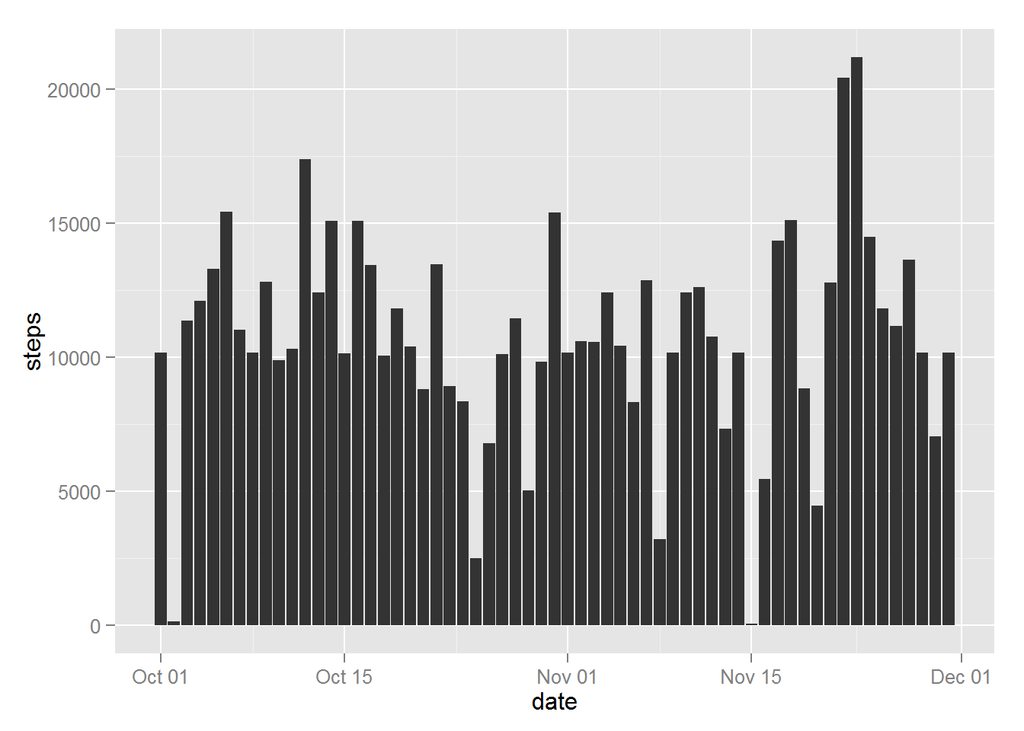

```r
sums.df.ext <-ldply(activity.sums.ext)
names(sums.df.ext) <-c("date", "steps")
sums.df.ext$date <- as.Date(sums.df.ext$date)
sums.plot.int <-ggplot(sums.df.ext, aes(x=date, y=steps)) + geom_bar(stat="identity")
sums.plot.int
```

### Are there differences in activty patterns between weekdays and weekends?

To test whether weekend activity is different than weekdays, the orginal daily pattern computed above was divided into weekend and weekday data frames and plotted below.

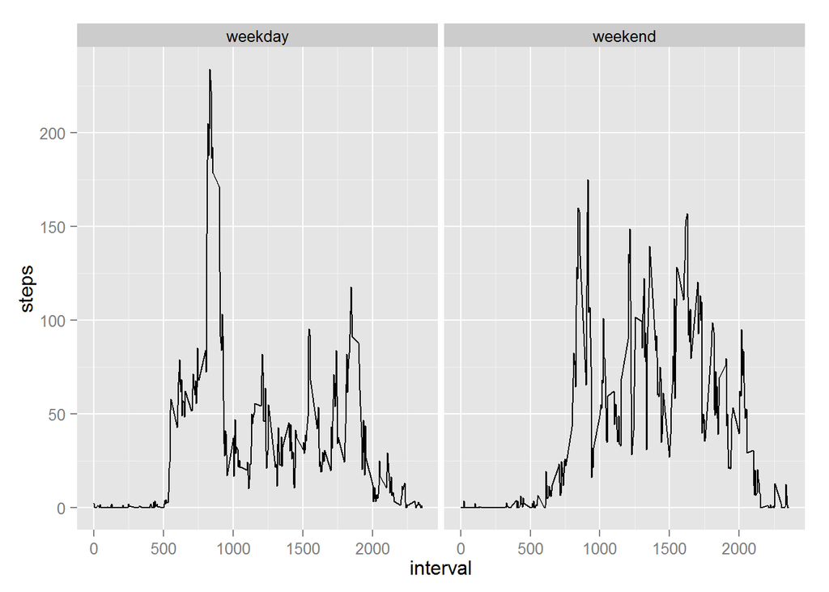

```r
patterns.df <-data.frame(pattern.weekday)
patterns.df$daytype <-"weekday"
names(patterns.df)[1]<-"interval"
names(patterns.df)[2] <-"steps"

patterns.wknd.df <-data.frame(pattern.weekend)
names(patterns.wknd.df)[1]<-"interval"
names(patterns.wknd.df)[2] <-"steps"
patterns.wknd.df$daytype <-"weekend"

patterns <-rbind(patterns.df, patterns.wknd.df)
patterns$daytype <-as.factor(patterns$daytype)
patterns$interval<-as.numeric(patterns$interval)

pp <-ggplot(patterns, aes(x=interval, y=steps)) + geom_line(aes(group=daytype))
pp <-pp + facet_grid(.~daytype)
pp
```